# Lecture 4 - Working with data on the command line

Simon Coetzee  
03/24/2022

## **Searching NGS File Formats**

This work, “Searching NGS File Formats”, is a derivative of [“Intro to Shell”](https://hbctraining.github.io/Intro-to-Shell/) by hbctraining, used under [CC BY](https://creativecommons.org/licenses/by/4.0/). “Searching NGS File Formats” is licensed under [CC BY](https://creativecommons.org/licenses/by/4.0/) by Simon Coetzee.

### Goals (grep and redirection)

- Search for characters or patterns in a text file using the grep command

### Goals (grep and redirection)

- Search for characters or patterns in a text file using the grep command
- Write to and append a file using output redirection

### Goals (grep and redirection)

- Search for characters or patterns in a text file using the grep command
- Write to and append a file using output redirection
- Use the pipe `|` character to chain together commands

### GREP

`grep` is a command-line utility for searching plain-text data sets for lines that match a *regular expression*. Its name comes from the `ed` command `g/re/p` (globally search for a regular expression and print matching lines), which has the same effect

`grep` syntax looks like

```
grep search_term filename
```

### FASTQ

Get some FASTQ data:

```
$ mkdir ~/lecture4
$ cp /data/*.fq ~/lecture4
$ ls ~/lecture4
Mov10_oe_1.subset.fq  Mov10_oe_2.subset.fq  Mov10_oe_3.subset.fq
$ head ~/lecture4/Mov10_oe_1.subset.fq
@HWI-ST330:304:H045HADXX:1:1101:1162:2055
NAGAACTTGGCGGCGAATGGGCTGACCGCTTCCTCGTGCTTTACGGTATCGCCGCTCCCGATTCGCAGCGCATCGCCTTCTATCGCCTTCTTGACGAGTT
+
#1=DDFFFHHHGHIJJJJIJJJGEGGAFGBHHEHGFBFFDEDECDDA==CB@BDDDDD?;B-<CBDDD>BBBBDDB5<@DDDCDDB@-9ACDDDDB?B<?
@HWI-ST330:304:H045HADXX:2:2111:20110:84312
GTCGAGGTGCCGTAAAGCACTAAATCGGAACCCTAAAGGGAGCCCCCGATTTAGAGCTTGACGGGGAAAGCCGGCGAACGTGGCGAGAAAGGAAGGGAAG
+
@@<FFFFDFFH>DEGFEGIJGJIJD9;CFCG;@;9?DDCD8AHGEF@84ADB?CD>3@CAACBBBDD@@@??90))5055(22-95<-5(:<ACBB@?8?
@HWI-ST330:304:H045HADXX:1:1214:9417:35291
CTCCAGACTCCGATCGTACAGCTTGAACTTCACATCTGAGGGCAGCAACGAGACCCCACGGGAGGCCACAGGAAAAAGCATGGGCCATAGCACCCAGCGC
```

### grep pattern FASTQ

Let's say we consider “bad” reads from our file as those that contain 10 consecutive Ns. We can `grep` for that.

```bash
$ grep NNNNNNNNNN Mov10_oe_1.subset.fq
```

This will return many lines of text!

But only the actual read, what if we wanted to see the whole record, all four lines?

### grep pattern FASTQ

To see what command line arguments we can use to modify `grep`s behavior, we can enter the following in your open bash shell

```
$ man grep
```

```
GREP(1)                User Commands                GREP(1)

NAME
       grep,  egrep,  fgrep, rgrep - print lines that match
       patterns

SYNOPSIS
       grep [OPTION...] PATTERNS [FILE...]
       grep [OPTION...] -e PATTERNS ... [FILE...]
       grep [OPTION...] -f PATTERN_FILE ... [FILE...]

DESCRIPTION
       grep searches for PATTERNS in each  FILE.   PATTERNS
```

### grep pattern FASTQ

Given that we are looking for four lines (one record), we want the line before the read, and two lines after the read.

```
-A NUM, --after-context=NUM
  Print NUM lines  of  trailing  context  after
  matching  lines.   Places a line containing a
  group  separator  (--)   between   contiguous
  groups   of   matches.    With   the   -o  or
  --only-matching option, this  has  no  effect
  and a warning is given.
-B NUM, --before-context=NUM
  Print  NUM  lines  of  leading context before
  matching lines.  Places a line  containing  a
  group   separator   (--)  between  contiguous
  groups  of   matches.    With   the   -o   or
  --only-matching  option,  this  has no effect
```

The `-B` and `-A` arguments for `grep` will be useful to return the matched line plus one before `-B 1` and two lines after `-A 2`.

### grep pattern FASTQ

The `-B` and `-A` arguments for `grep` will be useful to return the matched line plus one before `-B 1` and two lines after `-A 2`.

```
$ grep -B 1 -A 2 NNNNNNNNNN Mov10_oe_1.subset.fq
@HWI-ST330:304:H045HADXX:1:1101:1111:61397
CACTTGTAAGGGCAGGCCCCCTTCACCCTCCCGCTCCTGGGGGANNNNNNNNNNANNNCGAGGCCCTGGGGTAGAGGGNNNNNNNNNNNNNNGATCTTGG
+
@?@DDDDDDHHH?GH:?FCBGGB@C?DBEGIIIIAEF;FCGGI#########################################################
--
@HWI-ST330:304:H045HADXX:1:1101:1106:89824
CACAAATCGGCTCAGGAGGCTTGTAGAAAAGCTCAGCTTGACANNNNNNNNNNNNNNNNNGNGNACGAAACNNNNGNNNNNNNNNNNNNNNNNNNGTTGG
+
?@@DDDDDB1@?:E?;3A:1?9?E9?<?DGCDGBBDBF@;8DF#########################################################
--
```

### grep pattern FASTQ

The `-B` and `-A` arguments for `grep` will be useful to return the matched line plus one before `-B 1` and two lines after `-A 2`. The argument `--no-group-separator` will make sure that the `--` group separator lines between results are removed, so the output appears in the same format as the input.

```
$ grep -B 1 -A 2  --no-group-separator NNNNNNNNNN Mov10_oe_1.subset.fq
@HWI-ST330:304:H045HADXX:1:1101:1111:61397
CACTTGTAAGGGCAGGCCCCCTTCACCCTCCCGCTCCTGGGGGANNNNNNNNNNANNNCGAGGCCCTGGGGTAGAGGGNNNNNNNNNNNNNNGATCTTGG
+
@?@DDDDDDHHH?GH:?FCBGGB@C?DBEGIIIIAEF;FCGGI#########################################################
@HWI-ST330:304:H045HADXX:1:1101:1106:89824
CACAAATCGGCTCAGGAGGCTTGTAGAAAAGCTCAGCTTGACANNNNNNNNNNNNNNNNNGNGNACGAAACNNNNGNNNNNNNNNNNNNNNNNNNGTTGG
+
?@@DDDDDB1@?:E?;3A:1?9?E9?<?DGCDGBBDBF@;8DF#########################################################
```

### Invert grep

Another helpful argument for `grep` is the `-v` argument:

```
-v, --invert-match
      Invert  the sense of matching, to select non-
      matching lines.
```

basically returning everything that does not match the pattern.

we can examine a sample file from `/data` directory.

### Invert grep

```
$ cp /data/sample_sheet.txt ~/lecture4
$ cd ~/lecture4
$ cat sample_sheet.txt
sample  treatment
AR.1    vehicle
AR.2    vehicle
AR.3    vehicle
AR.DHT.1    DHT
AR.DHT.2    DHT
AR.DHT.3    DHT
```

we can see the metadata file for a hypothetical chipseq experiment.

### Invert grep

If we don't want to see the *vehicle* samples we can use the `-v` argument like this:

```
$ grep -v vehicle sample_sheet.txt
sample  treatment
AR.DHT.1    DHT
AR.DHT.2    DHT
AR.DHT.3    DHT
```

It returns all the lines in the file **except** the lines that contain *vehicle*.

### Redirecting Output To A File

## The command to write something to a file is `>`

We can use this to, instead of writing the output of a command to a terminal where we see it, write to a file to store that output. For example, we can store all the sequences that contain `NNNNNNNNNN` to a new file called `bad_reads.fq`

```
$ grep -B 1 -A 2 --no-group-separator NNNNNNNNNN Mov10_oe_1.subset.fq > bad_reads.fq
```

A new file is created called `bad_reads.fq`, and nothing is displayed on the screen.

We can confirm the file was created by entering:

```
$ ls -l
```

### Redirecting Output and Appending To A File

## The redirection command for appending something to an existing file is `>>`

If we were to execute the previous command on a new file `Mov10_oe_2.subset.fq`

```
$ grep -B 1 -A 2 --no-group-separator NNNNNNNNNN Mov10_oe_2.subset.fq > bad_reads.fq
```

It would overwrite the results, replacing them with new reads.

However, if we would like to append the bad reads from the new file to the end of the `bad_reads.fq` file, we would use the `>>` command instead.

```
$ grep -B 1 -A 2 --no-group-separator NNNNNNNNNN Mov10_oe_2.subset.fq >> bad_reads.fq
$ ls -l bad_reads.fq
```

### Redirecting Output To Another Command

IMO one of the coolest parts about the *nix environment.

## The redirection command for using the output of a command as input for a different command is `|` (pipe).

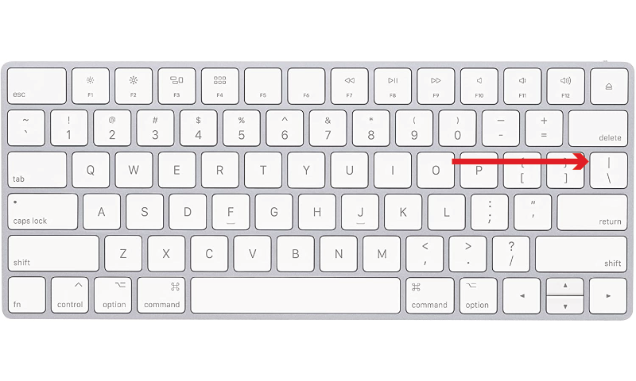

### Redirecting Output To Another Command

We can pipe the output of a command to `less` for example to be able to scroll through it at our leisure rather than watching it whiz by.

```
$ grep -B 1 -A 2 NNNNNNNNNN Mov10_oe_1.subset.fq | less
```

Or if we only want to see the first few lines of output, we could pipe it into `head`

```
$ grep -B 1 -A 2 NNNNNNNNNN Mov10_oe_1.subset.fq | head -n 8
```

### Redirecting Output To Another Command

Or maybe we only want to know *how many* lines from a file match our pattern. We could use the command `wc`.

`wc` stands for *w*ord *c*ount, and can count the number of words, lines, and characters in a piece of text given to it.

the argument `-l` indicates to count only the lines.

see `man wc` like we did with grep before to see more options.

```
$ grep NNNNNNNNNN Mov10_oe_1.subset.fq | wc -l
```

### Searching other files

Lets look at a gene annotation file like the GTF we saw before

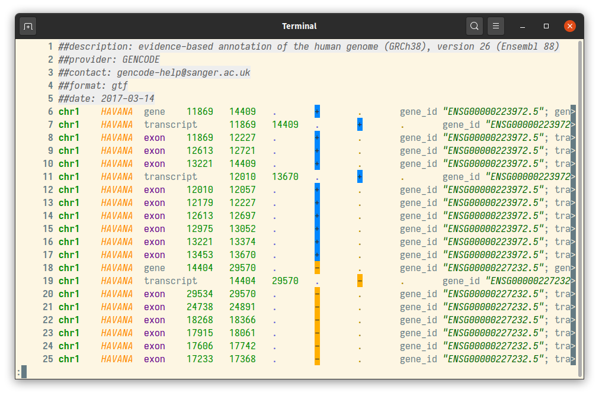

### Searching GTF

A sample GTF file can be found here:

`/data/gencode.v39.annotation.gtf`

```
$ cp /data/gencode.v39.annotation.gtf ~/lecture4
$ cd ~/lecture4
$ less gencode.v39.annotation.gtf
```

```
##description: evidence-based annotation of the human genome (GRCh38), version 39 (Ensembl 105)
##provider: GENCODE
##contact: gencode-help@ebi.ac.uk
##format: gtf
##date: 2021-09-02
chr1    HAVANA  gene    11869   14409   .   +   .   gene_id "ENSG00000223972.5"; gene_type "transcribed_unprocessed_pseudogene"; gene_name "DDX11L1"; level 2; hgnc_id "HGNC:37102"; havana_gene "OTTHUMG00000000961.2";
chr1    HAVANA  transcript  11869   14409   .   +   .   gene_id "ENSG00000223972.5"; transcript_id "ENST00000456328.2"; gene_type "transcribed_unprocessed_pseudogene"; gene_name "DDX11L1"; transcript_type "processed_transcript"; transcript_name "DDX11L1-202"; level 2; transcript_support_level "1"; h…
chr1    HAVANA  exon    11869   12227   .   +   .   gene_id "ENSG00000223972.5"; transcript_id "ENST00000456328.2"; gene_type "transcribed_unprocessed_pseudogene"; gene_name "DDX11L1"; transcript_type "processed_transcript"; transcript_name "DDX11L1-202"; exon_number 1; exon_id "ENSE00002234944.1"; …
chr1    HAVANA  exon    12613   12721   .   +   .   gene_id "ENSG00000223972.5"; transcript_id "ENST00000456328.2"; gene_type "transcribed_unprocessed_pseudogene"; gene_name "DDX11L1"; transcript_type "processed_transcript"; transcript_name "DDX11L1-202"; exon_number 2; exon_id "ENSE00003582793.1"; …
chr1    HAVANA  exon    13221   14409   .   +   .   gene_id "ENSG00000223972.5"; transcript_id "ENST00000456328.2"; gene_type "transcribed_unprocessed_pseudogene"; gene_name "DDX11L1"; transcript_type "processed_transcript"; transcript_name "DDX11L1-202"; exon_number 3; exon_id "ENSE00002312635.1"; …
```

### Some considerations when searching with grep

Searching for the word “gene” in a gtf file.

```
$ grep "gene" gencode.v39.annotation.gtf | head
chr1    HAVANA  gene    11869   14409   .   +   .   gene_id "ENSG00000223972.5"; gene_type "transcribed_unprocessed_pseudogene"; gene_name "DDX11L1"; level 2; hgnc_id "HGNC:37102"; havana_gene "OTTHUMG00000000961.2";
chr1    HAVANA  transcript  11869   14409   .   +   .   gene_id "ENSG00000223972.5"; transcript_id "ENST00000456328.2"; gene_type "transcribed_unprocessed_pseudogene"; gene_name "DDX11L1"; transcript_type "processed_transcript"; transcript_name "DDX11L1-202"; level 2; transcript_support_level "1"; h…
chr1    HAVANA  exon    11869   12227   .   +   .   gene_id "ENSG00000223972.5"; transcript_id "ENST00000456328.2"; gene_type "transcribed_unprocessed_pseudogene"; gene_name "DDX11L1"; transcript_type "processed_transcript"; transcript_name "DDX11L1-202"; exon_number 1; exon_id "ENSE00002234944.1"; …
chr1    HAVANA  exon    12613   12721   .   +   .   gene_id "ENSG00000223972.5"; transcript_id "ENST00000456328.2"; gene_type "transcribed_unprocessed_pseudogene"; gene_name "DDX11L1"; transcript_type "processed_transcript"; transcript_name "DDX11L1-202"; exon_number 2; exon_id "ENSE00003582793.1"; …
chr1    HAVANA  exon    13221   14409   .   +   .   gene_id "ENSG00000223972.5"; transcript_id "ENST00000456328.2"; gene_type "transcribed_unprocessed_pseudogene"; gene_name "DDX11L1"; transcript_type "processed_transcript"; transcript_name "DDX11L1-202"; exon_number 3; exon_id "ENSE00002312635.1"; …
chr1    HAVANA  transcript  12010   13670   .   +   .   gene_id "ENSG00000223972.5"; transcript_id "ENST00000450305.2"; gene_type "transcribed_unprocessed_pseudogene"; gene_name "DDX11L1"; transcript_type "transcribed_unprocessed_pseudogene"; transcript_name "DDX11L1-201"; level 2; transcript_suppor…
chr1    HAVANA  exon    12010   12057   .   +   .   gene_id "ENSG00000223972.5"; transcript_id "ENST00000450305.2"; gene_type "transcribed_unprocessed_pseudogene"; gene_name "DDX11L1"; transcript_type "transcribed_unprocessed_pseudogene"; transcript_name "DDX11L1-201"; exon_number 1; exon_id "ENSE00…
chr1    HAVANA  exon    12179   12227   .   +   .   gene_id "ENSG00000223972.5"; transcript_id "ENST00000450305.2"; gene_type "transcribed_unprocessed_pseudogene"; gene_name "DDX11L1"; transcript_type "transcribed_unprocessed_pseudogene"; transcript_name "DDX11L1-201"; exon_number 2; exon_id "ENSE00…
chr1    HAVANA  exon    12613   12697   .   +   .   gene_id "ENSG00000223972.5"; transcript_id "ENST00000450305.2"; gene_type "transcribed_unprocessed_pseudogene"; gene_name "DDX11L1"; transcript_type "transcribed_unprocessed_pseudogene"; transcript_name "DDX11L1-201"; exon_number 3; exon_id "ENSE00…
chr1    HAVANA  exon    12975   13052   .   +   .   gene_id "ENSG00000223972.5"; transcript_id "ENST00000450305.2"; gene_type "transcribed_unprocessed_pseudogene"; gene_name "DDX11L1"; transcript_type "transcribed_unprocessed_pseudogene"; transcript_name "DDX11L1-201"; exon_number 4; exon_id "ENSE00…
```

It occurs everywhere - even when it's not the type of interval we are looking for

### Some considerations when searching with grep

We can search for something that looks just like the “word” gene with the `-w` flag

```
$ grep -w "gene" gencode.v39.annotation.gtf | head
chr1    HAVANA  gene    11869   14409   .   +   .   gene_id "ENSG00000223972.5"; gene_type "transcribed_unprocessed_pseudogene"; gene_name "DDX11L1"; level 2; hgnc_id "HGNC:37102"; havana_gene "OTTHUMG00000000961.2";
chr1    HAVANA  gene    14404   29570   .   -   .   gene_id "ENSG00000227232.5"; gene_type "unprocessed_pseudogene"; gene_name "WASH7P"; level 2; hgnc_id "HGNC:38034"; havana_gene "OTTHUMG00000000958.1";
chr1    ENSEMBL gene    17369   17436   .   -   .   gene_id "ENSG00000278267.1"; gene_type "miRNA"; gene_name "MIR6859-1"; level 3; hgnc_id "HGNC:50039";
chr1    HAVANA  gene    29554   31109   .   +   .   gene_id "ENSG00000243485.5"; gene_type "lncRNA"; gene_name "MIR1302-2HG"; level 2; hgnc_id "HGNC:52482"; tag "ncRNA_host"; havana_gene "OTTHUMG00000000959.2";
chr1    ENSEMBL gene    30366   30503   .   +   .   gene_id "ENSG00000284332.1"; gene_type "miRNA"; gene_name "MIR1302-2"; level 3; hgnc_id "HGNC:35294";
chr1    HAVANA  gene    34554   36081   .   -   .   gene_id "ENSG00000237613.2"; gene_type "lncRNA"; gene_name "FAM138A"; level 2; hgnc_id "HGNC:32334"; havana_gene "OTTHUMG00000000960.1";
chr1    HAVANA  gene    52473   53312   .   +   .   gene_id "ENSG00000268020.3"; gene_type "unprocessed_pseudogene"; gene_name "OR4G4P"; level 2; hgnc_id "HGNC:14822"; havana_gene "OTTHUMG00000185779.1";
chr1    HAVANA  gene    57598   64116   .   +   .   gene_id "ENSG00000240361.2"; gene_type "transcribed_unprocessed_pseudogene"; gene_name "OR4G11P"; level 2; hgnc_id "HGNC:31276"; havana_gene "OTTHUMG00000001095.3";
chr1    HAVANA  gene    65419   71585   .   +   .   gene_id "ENSG00000186092.7"; gene_type "protein_coding"; gene_name "OR4F5"; level 2; hgnc_id "HGNC:14825"; havana_gene "OTTHUMG00000001094.4";
chr1    HAVANA  gene    89295   133723  .   -   .   gene_id "ENSG00000238009.6"; gene_type "lncRNA"; gene_name "ENSG00000238009"; level 2; tag "overlapping_locus"; havana_gene "OTTHUMG00000001096.2";
```

limiting the types of lines we get back.

### GREP -w

```
       -w, --word-regexp
              Select only those lines containing matches
              that form whole words.  The test  is  that
              the  matching  substring must either be at
              the beginning of the line, or preceded  by
              a    non-word    constituent    character.
              Similarly, it must be either at the end of
              the   line   or  followed  by  a  non-word
              constituent  character.   Word-constituent
              characters  are  letters,  digits, and the
              underscore.  This option has no effect  if
              -x is also specified.
```

### Some considerations when searching with grep

Same goes for when one is inverting a search.

```
$ grep -v "gene" gencode.v39.annotation.gtf
##description: evidence-based annotation of the human genome (GRCh38), version 39 (Ensembl 105)
##provider: GENCODE
##contact: gencode-help@ebi.ac.uk
##format: gtf
##date: 2021-09-02
```

### Some considerations when searching with grep

Almost every line as “gene” somewhere in the line.

```
$ grep -v -w "gene" gencode.v39.annotation.gtf | head
##description: evidence-based annotation of the human genome (GRCh38), version 39 (Ensembl 105)
##provider: GENCODE
##contact: gencode-help@ebi.ac.uk
##format: gtf
##date: 2021-09-02
chr1    HAVANA  transcript  11869   14409   .   +   .   gene_id "ENSG00000223972.5"; transcript_id "ENST00000456328.2"; gene_type "transcribed_unprocessed_pseudogene"; gene_name "DDX11L1"; transcript_type "processed_transcript"; transcript_name "DDX11L1-202"; level 2; transcript_support_level "1"; h…
chr1    HAVANA  exon    11869   12227   .   +   .   gene_id "ENSG00000223972.5"; transcript_id "ENST00000456328.2"; gene_type "transcribed_unprocessed_pseudogene"; gene_name "DDX11L1"; transcript_type "processed_transcript"; transcript_name "DDX11L1-202"; exon_number 1; exon_id "ENSE00002234944.1"; …
chr1    HAVANA  exon    12613   12721   .   +   .   gene_id "ENSG00000223972.5"; transcript_id "ENST00000456328.2"; gene_type "transcribed_unprocessed_pseudogene"; gene_name "DDX11L1"; transcript_type "processed_transcript"; transcript_name "DDX11L1-202"; exon_number 2; exon_id "ENSE00003582793.1"; …
chr1    HAVANA  exon    13221   14409   .   +   .   gene_id "ENSG00000223972.5"; transcript_id "ENST00000456328.2"; gene_type "transcribed_unprocessed_pseudogene"; gene_name "DDX11L1"; transcript_type "processed_transcript"; transcript_name "DDX11L1-202"; exon_number 3; exon_id "ENSE00002312635.1"; …
chr1    HAVANA  transcript  12010   13670   .   +   .   gene_id "ENSG00000223972.5"; transcript_id "ENST00000450305.2"; gene_type "transcribed_unprocessed_pseudogene"; gene_name "DDX11L1"; transcript_type "transcribed_unprocessed_pseudogene"; transcript_name "DDX11L1-201"; level 2; transcript_suppor…
```

### Some considerations when searching with grep

One must be careful that included in the results are not just areas where you have a substring.

`-w` can be helpful here too

```
$ grep -w gene gencode.v39.annotation.gtf | grep "ATP5MF"
chr6    HAVANA  gene    108907615   108907873   .   -   .   gene_id "ENSG00000228834.1"; gene_type "processed_pseudogene"; gene_name "ATP5MFP2"; level 1; hgnc_id "HGNC:21540"; tag "pseudo_consens"; havana_gene "OTTHUMG00000015333.2";
chr7    HAVANA  gene    99419749    99466197    .   -   .   gene_id "ENSG00000248919.7"; gene_type "protein_coding"; gene_name "ATP5MF-PTCD1"; level 1; hgnc_id "HGNC:38844"; tag "overlapping_locus"; havana_gene "OTTHUMG00000160779.2";
chr7    HAVANA  gene    99448475    99466186    .   -   .   gene_id "ENSG00000241468.8"; gene_type "protein_coding"; gene_name "ATP5MF"; level 2; hgnc_id "HGNC:848"; tag "overlapping_locus"; havana_gene "OTTHUMG00000154609.7";
chr9    HAVANA  gene    77040416    77040673    .   +   .   gene_id "ENSG00000232851.3"; gene_type "processed_pseudogene"; gene_name "ATP5MFP3"; level 1; hgnc_id "HGNC:21286"; tag "pseudo_consens"; havana_gene "OTTHUMG00000020052.2";
chr12   HAVANA  gene    6270168 6270425 .   -   .   gene_id "ENSG00000256103.2"; gene_type "processed_pseudogene"; gene_name "ATP5MFP5"; level 1; hgnc_id "HGNC:33611"; tag "pseudo_consens"; havana_gene "OTTHUMG00000168354.1";
chr15   HAVANA  gene    66414933    66415198    .   -   .   gene_id "ENSG00000261102.2"; gene_type "processed_pseudogene"; gene_name "ATP5MFP6"; level 1; hgnc_id "HGNC:33612"; tag "pseudo_consens"; havana_gene "OTTHUMG00000172827.2";
chr17   HAVANA  gene    64491523    64491789    .   +   .   gene_id "ENSG00000256826.1"; gene_type "processed_pseudogene"; gene_name "ATP5MFP4"; level 1; hgnc_id "HGNC:32451"; tag "pseudo_consens"; havana_gene "OTTHUMG00000132312.1";
chr21   HAVANA  gene    36388878    36389112    .   -   .   gene_id "ENSG00000224421.1"; gene_type "processed_pseudogene"; gene_name "ATP5MFP1"; level 1; hgnc_id "HGNC:849"; tag "pseudo_consens"; havana_gene "OTTHUMG00000086613.1";
```

### Some considerations when searching with grep

One must be careful that included in the results are not just areas where you have a substring.

`-w` can be helpful here too … but not always.

```
$ grep -w gene gencode.v39.annotation.gtf | grep -w "ATP5MF"
chr7    HAVANA  gene    99419749    99466197    .   -   .   gene_id "ENSG00000248919.7"; gene_type "protein_coding"; gene_name "ATP5MF-PTCD1"; level 1; hgnc_id "HGNC:38844"; tag "overlapping_locus"; havana_gene "OTTHUMG00000160779.2";
chr7    HAVANA  gene    99448475    99466186    .   -   .   gene_id "ENSG00000241468.8"; gene_type "protein_coding"; gene_name "ATP5MF"; level 2; hgnc_id "HGNC:848"; tag "overlapping_locus"; havana_gene "OTTHUMG00000154609.7";
```

### Some considerations when searching with grep

We can try to include the `"` marks in our search to isolate just the string `"ATP5MF"` rather than `ATP5MF`

```
$ grep -w gene gencode.v39.annotation.gtf | grep \"ATP5MF\"
chr7    HAVANA  gene    99448475    99466186    .   -   .   gene_id "ENSG00000241468.8"; gene_type "protein_coding"; gene_name "ATP5MF"; level 2; hgnc_id "HGNC:848"; tag "overlapping_locus"; havana_gene "OTTHUMG00000154609.7";
```

### Advanced GREP

## Just so you know it's there - regular expressions can be even more powerful:

There are certain meta-characters that are reserved in regex:

```
^: matches pattern at start of string
$: matches pattern at end of string
.: matches any character except new lines
[]: matches any of enclose characters
[^]: matches any characters *except* ones enclosed (note: is different from ^)
\: "escapes" meta-characters, allows literal matching
```

### Advanced GREP

One can do some quite sophisticated searching with grep using regular expressions. For these kinds of searches one can use “extended” grep or `egrep`. I'll use screenshots here to show what is being matched with color:

One can match a certain number of characters with `{x,y}`. Here we are looking for matches of any string of C’s and/or G’s that is six to twelve characters long using the pattern `[GC]{6,12}`.

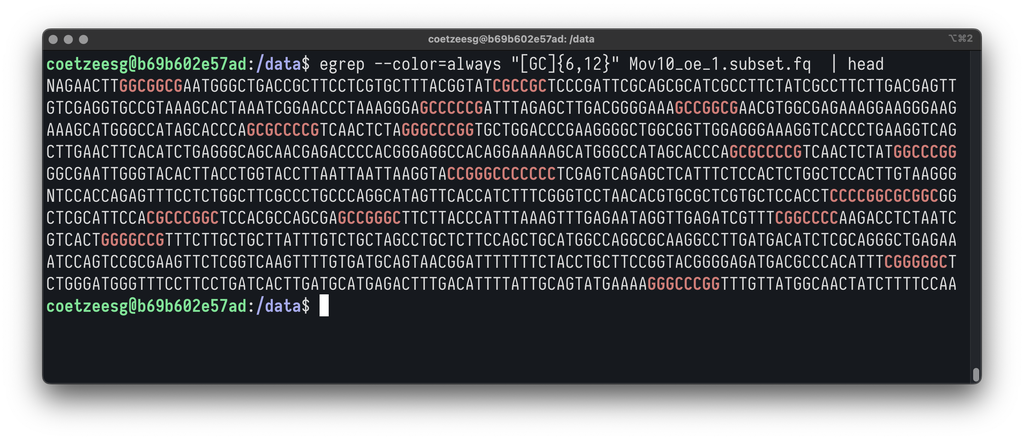

### Advanced GREP

## `+` The most prominent repetition modifier

Instead of asking for a specific length of match, one can ask for at least one match using the special symbol `+`

As an example we can search for a start codon `ATG` followed by any number of bases (at least one), and ending with a stop codon `TGA` using the pattern `ATG[ATGC]+TGA`

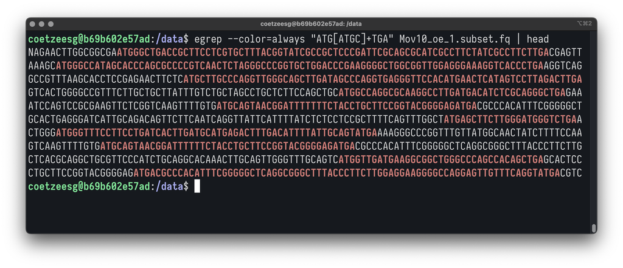

### Advanced GREP

We can also search for repetitive strings, where we want to search for the whole group of characters, not just one or two.

Here we search for `CAG` repeats between six and twelve repeats long with the pattern `(CAG){6,12}`. You'll note that we used parentheses instead of square brackets here.

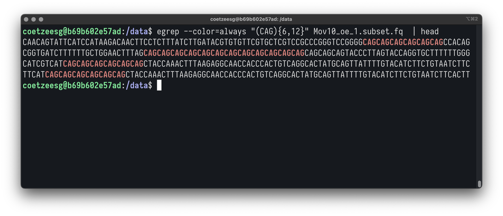

### Bonus: Cheating at wordle

[figure not shown]

```
$ cat /usr/share/dict/words | egrep '^m...h$' | egrep -v 'r|a|i|s|e|u|l|c'
month
```

### Bonus: Cheating at wordle

## Doesn't always work though

[figure not shown]

Starting at **CANTO**

```
cat /usr/share/dict/words | egrep '^.a...$' | egrep -v 'r|i|s|e|n|o' | grep c | grep t
batch
caput
catch
catty
hatch
latch
match
patch
tacky
watch
yacht
```

### Two More Commands

## `cut` is a command that extracts columns from files

## `sort` is a command used to sort the contents of a file in a particular order.

these commands both make use of columns of data.

### cut To Extract Columns

By default, `cut` expects columns in files to be separated by tabs. Like the GTF file above, and many other other common bioinformatics formats. However, with the argument `-d` we can specify a different delimiter. Some files like `.csv` files can have thier columns separated by a comma (`.csv` stands for comma separated values) and so we can cut columns from them with `cut -d","`

Here we can examine the chromosome and start coordinates from the GTF file.

The `-f` argument allows us to chose the *f*ield or column we want to see

```
$ cut -f1,4 gencode.v39.annotation.gtf | head
##description: evidence-based annotation of the human genome (GRCh38), version 39 (Ensembl 105)
##provider: GENCODE
##contact: gencode-help@ebi.ac.uk
##format: gtf
##date: 2021-09-02
chr1    11869
chr1    11869
chr1    11869
chr1    12613
chr1    13221
```

### cut To Extract Columns

By default, `cut` expects columns in files to be separated by tabs. Like the GTF file above, and many other other common bioinformatics formats. However, with the argument `-d` we can specify a different delimiter. Some files like `.csv` files can have thier columns separated by a comma (`.csv` stands for comma separated values) and so we can cut columns from them with `cut -d","`

Here we can examine the chromosome and start coordinates from the GTF file.

The `-f` argument allows us to chose the *f*ield or column we want to see

[output not shown]

### sort To Sort based on Columns

By default, `sort` sorts a text file by alpha/numeric order, across all columns. It is able to, after sorting, showing only unique columns with the argument `-u`.

```
$ cut -f1,4 gencode.v39.annotation.gtf | wc -l
3241007
$ cut -f1,4 gencode.v39.annotation.gtf | sort -u | wc -l
624652
```

### sort To Sort based on Columns

`sort` is also able to sort files based on specific columns with the `-k` argument, and therein able to sort by specific methods.

`general-numeric -g, human-numeric -h, month -M, numeric -n, random -R, version -V`

Here we sort column 2 numerically.

```
sort -k2,2n gencode.v39.annotation.gtf | head -5
```

Here we sort column 2 reverse numerically.

```
sort -k2,2nr gencode.v39.annotation.gtf | head -5
```

### sort Chromosome names

Lets make a file of chromosome names to see how some of the sorts work:

Also just to place things on multiple lines, here we demonstrate that the `\` can allow you continue on the next line without executing your command. This can be helpful for readability purposes.

```
$ cut -f1 /data/gencode.v39.annotation.gtf | \
> grep -v "#" | \
> sort -u > ~/lecture4/chromosome_names.txt
$ cd ~/lecture4
```

### sort Chromosome names

```
$ shuf chromosome_names.txt | sort -n
chr1
chr10
chr11
chr12
chr13
chr14
chr15
chr16
chr17
chr18
chr19
chr2
chr20
chr21
chr22
chr3
chr4
chr5
chr6
chr7
chr8
chr9
chrX
chrY
```

```
shuf chromosome_names.txt | sort -V
chr1
chr2
chr3
chr4
chr5
chr6
chr7
chr8
chr9
chr10
chr11
chr12
chr13
chr14
chr15
chr16
chr17
chr18
chr19
chr20
chr21
chr22
chrX
chrY
```